# Project 3

STATS 220 Semester One 2025

Bill Liu

2025-04-24

## Introduction

The two words I picked are “Night sky”. This is because it’s something that’s objectively nice to look at, its aesthetically pleasing view would be something that people would want to capture and so I expected there to be a lot of photography for it. [Night Sky Pexels search](https://www.pexels.com/search/night%20sky/)

First row of photos

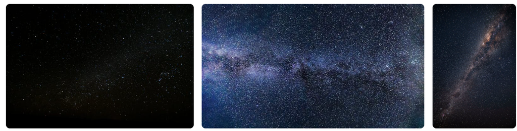

**Three features:**

1. I noticed that most of the photos include a sky full of stars, usually with a visible milky way somewhere in the image.
2. Most images have the colour of the sky as a shade of blue, whether it’s lighter or so dark it just looks black.
3. Many photos have something else in the image besides the night sky, like the moon or the landscape below it.

```r
selected_photos %>% select(url) %>% knitr::kable()
```

| url |
| --- |
| https://www.pexels.com/photo/starry-sky-998641/ |
| https://www.pexels.com/photo/blue-universe-956981/ |
| https://www.pexels.com/photo/stars-1257860/ |
| https://www.pexels.com/photo/silhouette-of-trees-during-nighttime-631477/ |
| https://www.pexels.com/photo/full-moon-illustration-713664/ |
| https://www.pexels.com/photo/milky-way-galaxy-433155/ |
| https://www.pexels.com/photo/photo-of-night-sky-1154610/ |
| https://www.pexels.com/photo/cluster-of-stars-1341279/ |
| https://www.pexels.com/photo/moon-and-stars-813269/ |
| https://www.pexels.com/photo/sky-with-stars-illustration-957061/ |
| https://www.pexels.com/photo/silhouette-photo-of-person-sitting-on-boardwalk-at-sunset-2531237/ |
| https://www.pexels.com/photo/clouds-under-full-moon-239107/ |
| https://www.pexels.com/photo/silhouette-photo-of-trees-during-night-time-365633/ |
| https://www.pexels.com/photo/brown-rocky-mountain-photography-2098427/ |
| https://www.pexels.com/photo/scenic-view-of-rocky-mountain-during-evening-1624438/ |
| https://www.pexels.com/photo/road-under-cloudy-sky-416920/ |
| https://www.pexels.com/photo/silhouette-of-trees-under-moon-1144690/ |
| https://www.pexels.com/photo/silhouette-of-mountain-under-starry-night-2387877/ |
| https://www.pexels.com/photo/silhouette-of-trees-under-starry-night-1361215/ |
| https://www.pexels.com/photo/milky-way-illustration-1169754/ |

## Key features

```r
mean_caption_length <- selected_photos$caption %>% nchar() %>% mean(na.rm = TRUE)
sum_islandscape <- sum(selected_photos$is_landscape == "Yes",na.rm = TRUE)
mean_aspect_ratio <- selected_photos$aspect_ratio %>% mean(na.rm = TRUE)

grouped_photos <- selected_photos %>%
  group_by(is_landscape) %>%
  summarise(aspect_ratio_mean = mean(aspect_ratio, na.rm = TRUE))
mean_aspect_landscape <- grouped_photos$aspect_ratio_mean[1]
mean_aspect_not_landscape <- grouped_photos$aspect_ratio_mean[2]
```

The average length of a caption has 108 characters.

The mean aspect ratio of the selected photos is 1.27.

The amount of photos that are landscape are 13 out of the total 20 selected.

## Creativity

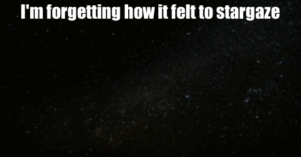

I created an animated gif with the skills we learned from Modules 1 and 2. I took the images from the selected photos and assigned it to a frame, each frame was sized the same for consistency. The images were annotated and the frames were put together by a vector then animated. I demonstrated creativity by going further in module 1 by finding extra functions in the Magick package to tell a story. I used the image_blur function to make the images of the animated gif more blurry with each frame, with the caption “I’m forgetting how it felt to stargaze” to generate a eerie kind of feeling about forgetting the simple things in life that brought joy. Side note I had used the variable landscape instead of small for the gif creation process to be more smooth, and also because the resolution of the images from the small variable were too blurry for my desired dimensions.

## Learning reflection

One important idea I had learnt from Module 3 is the usefulness of mutating data. I messed around quite a bit with the mutation of the photo data to see what new data frames could be created in the selected photos, this allowed me to see the different things you could do with mutation and to help me find what information I actually wanted. Creating new categories is really useful when you want to get specific information from the data that you’ve collected, and makes comparisons and analysis a lot easier. I also found that the filter tool was really helpful to further help me find what I wanted. I am curious about more ways of data processing, I want to know many ways of it and how else it gets transformed into the selected important information other than the way we did it in this project.

## Appendix

```r
#https://www.pexels.com/search/night%20sky/

#The main colours that are used in the photos are black and dark blue
#The photos typically get a few hundred or a few thousand likes
#There are more landscape photos than portraits

library(tidyverse)
library(httr)
library(magick)

api_key <- "x0CVF3ges6OlTPhkLkosJEdCsvgLnEo2Spx4zwweH0dGEMoatm04kxkD"

url <- "https://api.pexels.com/v1/search?query=night+sky&per_page=80"

response <- httr::GET(url,
                      add_headers(Authorization = api_key))

data <- httr::content(response,
                      as = "parsed",
                      type = "application/json")

photo_data <- tibble(photos = data$photos) %>%
  unnest_wider(photos) %>%
  unnest_wider(src)

selected_photos <- photo_data %>% #create selected photos
  mutate(is_landscape = ifelse(width > height, "Yes", "No")) %>% #make category Yes to is_landscape if width is more than height and No otherwise
  mutate(aspect_ratio = width / height) %>% #find the aspect ratio by dividing the width by hegiht
  mutate(caption = paste(alt, "by", photographer)) %>% #make a caption by combining the alt and the photographer
  filter(aspect_ratio > 0.3) %>% #filter out images that have heights way longer than width
    slice(1:20) #choosing the first 20 photos from the filtered list

write_csv(selected_photos, "selected_photos.csv")

mean_caption_length <- selected_photos$caption %>% nchar() %>% mean(na.rm = TRUE)
sum_islandscape <- sum(selected_photos$is_landscape == "Yes",na.rm = TRUE)
mean_aspect_ratio <- selected_photos$aspect_ratio %>% mean(na.rm = TRUE)

grouped_photos <- selected_photos %>%
  group_by(is_landscape) %>%
  summarise(aspect_ratio_mean = mean(aspect_ratio, na.rm = TRUE))
mean_aspect_landscape <- grouped_photos$aspect_ratio_mean[1]
mean_aspect_not_landscape <- grouped_photos$aspect_ratio_mean[2]

frame1 <- image_read(selected_photos$landscape[1]) %>% image_scale("500x750") %>%
  image_blur(1, 1) %>%
  image_annotate(text = "I'm forgetting how it felt to stargaze",
                 color = "#FFFFFF",
                 size = 30,
                 font = "Impact",
                 gravity = "north")
frame2 <- image_read(selected_photos$landscape[2]) %>% image_scale("500x750") %>%
  image_blur(3, 2) %>%
  image_annotate(text = "I'm forgetting how it felt to stargaze",
                 color = "#FFFFFF",
                 size = 30,
                 font = "Impact",
                 gravity = "north")
frame3 <- image_read(selected_photos$landscape[3]) %>% image_scale("500x750") %>%
  image_blur(5, 4) %>%
  image_annotate(text = "I'm forgetting how it felt to stargaze",
                 color = "#FFFFFF",
                 size = 30,
                 font = "Impact",
                 gravity = "north")
frame4 <- image_read(selected_photos$landscape[4]) %>% image_scale("500x750") %>%
  image_blur(10, 6) %>%
  image_annotate(text = "TI'm forgetting how it felt to stargaze",
                 color = "#FFFFFF",
                 size = 30,
                 font = "Impact",
                 gravity = "north")
frame5 <- image_read(selected_photos$landscape[5]) %>% image_scale("500x750") %>%
  image_blur(15, 8) %>%
  image_annotate(text = "I'm forgetting how it felt to stargaze",
                 color = "#FFFFFF",
                 size = 30,
                 font = "Impact",
                 gravity = "north")
frame6 <- image_read(selected_photos$landscape[6]) %>% image_scale("500x750") %>%
  image_blur(20, 10) %>%
  image_annotate(text = "I'm forgetting how it felt to stargaze",
                 color = "#FFFFFF",
                 size = 30,
                 font = "Impact",
                 gravity = "north")
frames <- c(frame1, frame2, frame3, frame4, frame5, frame6)
animation <- image_animate(frames, fps = 1)
image_write(animation, "creativity.gif")
```

````r
---
title: "Project 3"
subtitle: "STATS 220 Semester One 2025"
author: "Bill Liu"
date: "2025-04-24"
output:
  html_document:
    code_folding: hide
---

```{r setup, include=FALSE}
knitr::opts_chunk$set(echo=TRUE, message=FALSE, warning=FALSE, error=FALSE)
library(tidyverse)
selected_photos <- read_csv("selected_photos.csv")

```

## Introduction

The two words I picked are “Night sky”. This is because it’s something that’s objectively nice to look at, its aesthetically pleasing view would be something that people would want to capture and so I expected there to be a lot of photography for it.
[Night Sky Pexels search](https://www.pexels.com/search/night%20sky/)

First row of photos
![](top_photos.png)

**Three features:**

1. I noticed that most of the photos include a sky full of stars, usually with a visible milky way somewhere in the image.

2. Most images have the colour of the sky as a shade of blue, whether it’s lighter or so dark it just looks black.

3. Many photos have something else in the image besides the night sky, like the moon or the landscape below it.

```{r}
selected_photos %>% select(url) %>% knitr::kable()
```

## Key features
```{r}
mean_caption_length <- selected_photos$caption %>% nchar() %>% mean(na.rm = TRUE)
sum_islandscape <- sum(selected_photos$is_landscape == "Yes",na.rm = TRUE)
mean_aspect_ratio <- selected_photos$aspect_ratio %>% mean(na.rm = TRUE)

grouped_photos <- selected_photos %>%
  group_by(is_landscape) %>%
  summarise(aspect_ratio_mean = mean(aspect_ratio, na.rm = TRUE))
mean_aspect_landscape <- grouped_photos$aspect_ratio_mean[1]
mean_aspect_not_landscape <- grouped_photos$aspect_ratio_mean[2]
```
The average length of a caption has `r round(mean_caption_length, 0)` characters.

The mean aspect ratio of the selected photos is `r round(mean_aspect_ratio, 2)`.

Landscape photos have an average aspect ratio of `r round(mean_aspect_landscape, 2)`. while non landscape (portrait/square) photos have an average aspect ratio of `r
round(mean_aspect_not_landscape, 2)`.

The amount of photos that are landscape are `r sum_islandscape` out of the total `r nrow(selected_photos) ` selected.

## Creativity
![](creativity.gif)

I created an animated gif with the skills we learned from Modules 1 and 2. I took the images from the selected photos and assigned it to a frame, each frame was sized the same for consistency. The images were annotated and the frames were put together by a vector then animated. I demonstrated creativity by going further in module 1 by finding extra functions in the Magick package to tell a story. I used the image_blur function to make the images of the animated gif more blurry with each frame, with the caption "I'm forgetting how it felt to stargaze" to generate a eerie kind of feeling about forgetting the simple things in life that brought joy. Side note I had used the variable landscape instead of small for the gif creation process to be more smooth, and also because the resolution of the images from the small variable were too blurry for my desired dimensions.

## Learning reflection

One important idea I had learnt from Module 3 is the usefulness of mutating data. I messed around quite a bit with the mutation of the photo data to see what new data frames could be created in the  selected photos, this allowed me to see the different things you could do with mutation and to help me find what information I actually wanted. Creating new categories is really useful when you want to get specific information from the data that you've collected, and makes comparisons and analysis a lot easier. I also found that the filter tool was really helpful to further help me find what I wanted. I am curious about more ways of data processing, I want to know many ways of it and how else it gets transformed into the selected important information other than the way we did it in this project.

## Appendix

```{r file='exploration.R', eval=FALSE, echo=TRUE}

```
```{r file='project3_report.Rmd', eval=FALSE, echo=TRUE}

```
````